# Reproducible Research Assignment 2

Yanyu

October 4, 2017

# Determine the most harmful weather events with respect to population health and economic consequences

knitr::opts_chunk$set(echo = TRUE)

## Synopsis

In this work we analyze the U.S. National Oceanic and Atmospheric Administration’s (NOAA) storm database which tracks characteristics of major storms and weather events in the United States. The data includes when and where these events occur, as well as estimates of any fatalities, injuries, property and corn damage. The goal of the work is to find out the most harmful weather events with respect to population health and economic consequences.

1. Read data

```r
library(R.utils) #can't read origin file from bz2 to csv
```

```r
download.file("https://d396qusza40orc.cloudfront.net/repdata%2Fdata%2FStormData.csv.bz2", "StormData.csv.bz2")
bunzip2("D:\\DATA\\coursera\\Data Scientist\\datasciencecoursera\\Reproducible Research\\Assignment 2\\StormData.csv.bz2")
stormdata <- read.csv("D:\\DATA\\coursera\\Data Scientist\\datasciencecoursera\\Reproducible Research\\Assignment 2\\StormData.csv")
```

```r
head(stormdata)
```

```
##   STATE__           BGN_DATE BGN_TIME TIME_ZONE COUNTY COUNTYNAME STATE
## 1       1  4/18/1950 0:00:00     0130       CST     97     MOBILE    AL
## 2       1  4/18/1950 0:00:00     0145       CST      3    BALDWIN    AL
## 3       1  2/20/1951 0:00:00     1600       CST     57    FAYETTE    AL
## 4       1   6/8/1951 0:00:00     0900       CST     89    MADISON    AL
## 5       1 11/15/1951 0:00:00     1500       CST     43    CULLMAN    AL
## 6       1 11/15/1951 0:00:00     2000       CST     77 LAUDERDALE    AL
##    EVTYPE BGN_RANGE BGN_AZI BGN_LOCATI END_DATE END_TIME COUNTY_END
## 1 TORNADO         0                                               0
## 2 TORNADO         0                                               0
## 3 TORNADO         0                                               0
## 4 TORNADO         0                                               0
## 5 TORNADO         0                                               0
## 6 TORNADO         0                                               0
##   COUNTYENDN END_RANGE END_AZI END_LOCATI LENGTH WIDTH F MAG FATALITIES
```

[output cut: 20 more lines]

## Data Processing

2. Select useful data

```r
stormdamages <- stormdata[c("STATE", "EVTYPE", "FATALITIES", "INJURIES", "PROPDMG", "PROPDMGEXP", "CROPDMG", "CROPDMGEXP")]
head(stormdamages)
```

```
##   STATE  EVTYPE FATALITIES INJURIES PROPDMG PROPDMGEXP CROPDMG CROPDMGEXP
## 1    AL TORNADO          0       15    25.0          K       0
## 2    AL TORNADO          0        0     2.5          K       0
## 3    AL TORNADO          0        2    25.0          K       0
## 4    AL TORNADO          0        2     2.5          K       0
## 5    AL TORNADO          0        2     2.5          K       0
## 6    AL TORNADO          0        6     2.5          K       0
```

3. Clean data, convert data int intratable data

```r
unique(stormdamages$PROPDMGEXP)
```

```
##  [1] K M   B m + 0 5 6 ? 4 2 3 h 7 H - 1 8
## Levels:  - ? + 0 1 2 3 4 5 6 7 8 B h H K m M
```

```r
unique(stormdamages$CROPDMGEXP)
```

```
## [1]   M K m B ? 0 k 2
## Levels:  ? 0 2 B k K m M
```

```r
stormdamages[stormdamages$PROPDMGEXP == "K", ]$PROPDMG <- stormdamages[stormdamages$PROPDMGEXP == "K", ]$PROPDMG * 1000
stormdamages[stormdamages$PROPDMGEXP == "M", ]$PROPDMG <- stormdamages[stormdamages$PROPDMGEXP == "M", ]$PROPDMG * 1000000
stormdamages[stormdamages$PROPDMGEXP == "m", ]$PROPDMG <- stormdamages[stormdamages$PROPDMGEXP == "m", ]$PROPDMG * 1000000
stormdamages[stormdamages$PROPDMGEXP == "B", ]$PROPDMG <- stormdamages[stormdamages$PROPDMGEXP == "B", ]$PROPDMG * 1000000000
stormdamages[stormdamages$CROPDMGEXP == "K", ]$CROPDMG <- stormdamages[stormdamages$CROPDMGEXP == "K", ]$CROPDMG * 1000
stormdamages[stormdamages$CROPDMGEXP == "k", ]$CROPDMG <- stormdamages[stormdamages$CROPDMGEXP == "k", ]$CROPDMG * 1000
stormdamages[stormdamages$CROPDMGEXP == "M", ]$CROPDMG <- stormdamages[stormdamages$CROPDMGEXP == "M", ]$CROPDMG * 1000000
stormdamages[stormdamages$CROPDMGEXP == "m", ]$CROPDMG <- stormdamages[stormdamages$CROPDMGEXP == "m", ]$CROPDMG * 1000000
stormdamages[stormdamages$CROPDMGEXP == "B", ]$CROPDMG <- stormdamages[stormdamages$CROPDMGEXP == "B", ]$CROPDMG * 1000000000
# change unit

head(stormdamages)
```

```
##   STATE  EVTYPE FATALITIES INJURIES PROPDMG PROPDMGEXP CROPDMG CROPDMGEXP
## 1    AL TORNADO          0       15   25000          K       0
## 2    AL TORNADO          0        0    2500          K       0
## 3    AL TORNADO          0        2   25000          K       0
## 4    AL TORNADO          0        2    2500          K       0
## 5    AL TORNADO          0        2    2500          K       0
## 6    AL TORNADO          0        6    2500          K       0
```

## Result

```r
#create subset of fatality and injuries related to event type
library(dplyr)
injuries <- stormdamages %>% filter(stormdamages$INJURIES >0) %>% group_by(EVTYPE) %>% summarise(totalInjuries = sum(INJURIES)) %>% arrange(desc(totalInjuries))
fatalities <- stormdamages %>% filter(stormdamages$FATALITIES >0) %>% group_by(EVTYPE) %>% summarise(totalFatalities = sum(FATALITIES)) %>% arrange(desc(totalFatalities))
head(fatalities)
```

```
## # A tibble: 6 x 2
##           EVTYPE totalFatalities
##           <fctr>           <dbl>
## 1        TORNADO            5633
## 2 EXCESSIVE HEAT            1903
## 3    FLASH FLOOD             978
## 4           HEAT             937
## 5      LIGHTNING             816
## 6      TSTM WIND             504
```

```r
head(injuries)
```

```
## # A tibble: 6 x 2
##           EVTYPE totalInjuries
##           <fctr>         <dbl>
## 1        TORNADO         91346
## 2      TSTM WIND          6957
## 3          FLOOD          6789
## 4 EXCESSIVE HEAT          6525
## 5      LIGHTNING          5230
## 6           HEAT          2100
```

Plot

[figure not shown]

```r
par(mfrow = c(1,2), mar = c(10,5,3,2))

topFatalities <- fatalities[1:10,]
barplot(topFatalities$totalFatalities, las = 2, cex.axis = .7, names.arg = topFatalities$EVTYPE, main = "Top 10 Storms by Death Count", ylab = "number of fatalities", col = "sky blue")

topInjuries <- injuries[1:10,]
barplot(topInjuries$totalInjuries, las = 2, cex.axis = .7, names.arg = topInjuries$EVTYPE, main = "Top 10 Storms by Death Count", ylab = "number of fatalities", col = "sky blue")
```

### Determine which kind of weather type causes the most harmful situation with respect to economics consequences(Interm of Property damages and Crop damages).

```r
crops <- stormdamages %>% filter(stormdamages$CROPDMG >0) %>% group_by(EVTYPE) %>% summarise(totalcrops = sum(CROPDMG)) %>% arrange(desc(totalcrops))

property <- stormdamages %>% filter(stormdamages$PROPDMG >0) %>% group_by(EVTYPE) %>% summarise(totalproperty = sum(PROPDMG)) %>% arrange(desc(totalproperty))
head(crops)
```

```
## # A tibble: 6 x 2
##        EVTYPE  totalcrops
##        <fctr>       <dbl>
## 1     DROUGHT 13972566000
## 2       FLOOD  5661968450
## 3 RIVER FLOOD  5029459000
## 4   ICE STORM  5022113500
## 5        HAIL  3025954473
## 6   HURRICANE  2741910000
```

```r
head(property)
```

```
## # A tibble: 6 x 2
##              EVTYPE totalproperty
##              <fctr>         <dbl>
## 1             FLOOD  144657709807
## 2 HURRICANE/TYPHOON   69305840000
## 3           TORNADO   56937160779
## 4       STORM SURGE   43323536000
## 5       FLASH FLOOD   16140812067
## 6              HAIL   15732267048
```

Merge the data

```r
total <- merge(property, crops, by = "EVTYPE")
total$totaldamage = total$totalcrops + total$totalproperty
total <- arrange(total, desc(totaldamage))
```

Plot

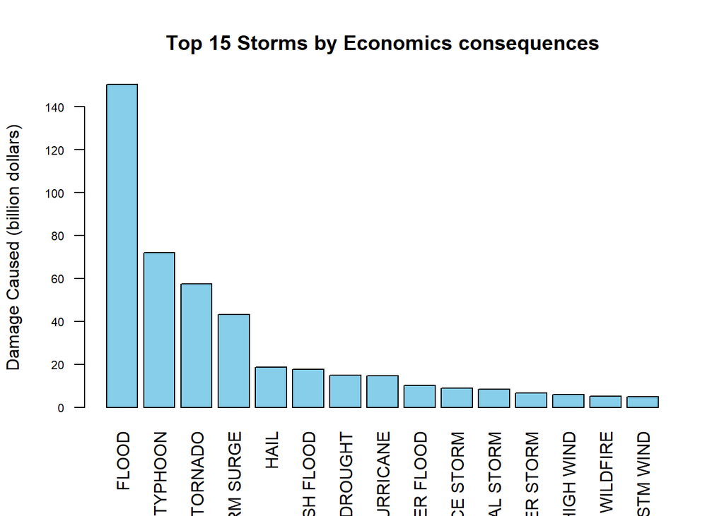

```r
top <- total[1:15,]
barplot(top$totaldamage/1000000000, las = 2, cex.axis = .7, names.arg = top$EVTYPE, main = "Top 15 Storms by Economics consequences", ylab = "Damage Caused (billion dollars)", col = "sky blue")
```